# GEOG 5680 6680 13 R and GitHub

Simon Brewer Geography Department University of Utah

19 May, 2024

# Introduction

In this lab, we will look at how to set up R to work with GitHub, a versioning service. The idea behind these versioning services is that they allow you to set up a *repository* holding your code and data through their website. You can then *clone* this to get a local copy on your computer. As you then modify and improve your code, you send or *push* these changes back to the repository held by the service. If you work on multiple computers, you can then continue to work on the same code base, by *pulling* the new changes down to whatever computer you are working on, working on the code, then pushing the new changes back.

This also helps facilitate collaborative projects. Multiple people can work on code, each pushing their changes back to the main repository. The owner of the code can then decide which changes to approve and which to reject. Projects can also be *forked*, where a copy is made, and can then be modified separately from the main code branch. This allows you to take someone else’s code and modify it for your own purposes without affecting the original project.

This lab is a little different from the other labs in this class, as it requires you to set up an account with GitHub (it’s free), and then set up R to communicate with your account. Once you have done this once, you will be able to use this service with any of your code.

Before starting, remember to create a working directory (e.g. `module13`). Next download the files for today’s lab from the Canvas page and move them to this directory. You’ll need the following files:

- Mauna Loa atmospheric CO2 concentration (in csv format): *co2_mm_mlo.csv*

# git

git is a version control system designed by the developers of the Linux kernel. It is free to use and install and offers a whole bunch of ways to help with coding work, particularly when this is collaborative. This includes:

- version control to avoid overwriting new code with old
- version storage to find older modifications
- tracking for issues and bugs
- commenting system to make it clear(ish) what changes have been made and why

The whole system works through repositories: a set of files dedicated to a given project. This is not restricted to R files, and can be used with most computer languages, documents and files.

The examples used here are based on the information available at [happygitwithr](https://happygitwithr.com). This website has much more extensive instructions on the use of git and R (and git on its own), and is an excellent place to follow up.

# GitHub

GitHub is one of several online hosting sites, that provide cloud-based storage for your git repositories. This (and git) now integrate quite seamlessly with R, and particularly with RStudio, so in this lab, we’ll go through the steps of setting up R and GitHub to play nicely together.

The overall setup scheme is as follows:

1. Create an account at GitHub
2. Make sure R/RStudio is up-to-date
3. Install git
4. Link git to your account
5. Connect R to git and GitHub

## Setting up a GitHub account

Go to this site: https://github.com and follow the instructions. Choose your username wisely - remember that this is way that potential employers can see your work!

**UPDATE 2022** You will also need to create a Personal Access Token (PAT).

- Log in to github, then click your profile photo, then click `Settings` (top right corner).
- In the left sidebar, click `Developer settings`
- In the left sidebar, click `Personal access tokens`
- Click `Generate new token`
- Give your token a descriptive name
- It’s worth setting an expiration time for your token. Pick 30 days from the drop-down menu, which will cover the duration of this class. After that, you will need to repeat these steps to generate a new token
- Below this you have the option to select the scopes, or permissions, you’d like to grant this token. This limits access to different parts of your account. For now, just check the box labelled `repo`
- Click `Generate token`

On the next page, you will see the new token. This is a long string of characters starting with the characters `ghp_`. Copy this into a word document or text file so that you can use it later.

## Update R and RStudio

As you have probably just installed R and RStudio, you can skip this step. If however, your versions are out of date, you should go to

- http://cran.r-project.org for R
- https://www.rstudio.com for RStudio

And follow the usual instructions for installing the latest versions of these.

## Install git

git is the underlying software that manages the repositories, keeps files current and copies and sends files between computers, so we need to install this first so that R can use it.

### Windows

The easiest way to install git is using [Git for windows](https://gitforwindows.org). This is a self contained installer; download it and run it and follow all the usual prompts.

### Mac OSX

The easiest way to install git on a Mac is by installing the XCode command line tools. Open a terminal and enter the following command to do so:

```
xcode-select --install
```

This can take a little time, but when finished will provide you with a wide range of useful tools for programming.

### Linux

Use your favorite package manager to install git directly.

Ubuntu or Debian Linux:

```
sudo apt-get install git
```

Fedora or RedHat Linux:

```
sudo yum install git
```

You can also get the latest version of git [here](https://git-scm.com/downloads).

## Setting up git

Once the installation is complete, open a terminal to check that git is working. There are several options to access a terminal, but an easy one is to use the terminal in RStudio. Open RStudio, then go to [Tools] > [Terminal] > [New Terminal], and you should get a new tab in the console panel. Go to this, and type the following to check that git is working:

```
which git
```

and

```
git --version
```

If this doesn’t work, open [Tools] > [General options]. Select the Terminal from the left hand side, and look at the drop down list titled [Open new terminal with..]. If there is an open for `git bash`, select this and try again.

On Mac or Linux, you can also use a regular terminal, as long as it is running bash. On Windows, you can access Git Bash from the Start menu.

If this works, the next steps are to tell git your name and email address. The email address should be the address that you registered with GitHub, but the name can be your real name. Type the following in your terminal:

```
git config --global user.name 'Jane Doe'
git config --global user.email 'jane@example.com'
```

To check that this has been correctly entered:

```
git config --global --list
```

# Connect to GitHub

In this section, we will walk through the steps of connecting to GitHub for the first time, and both pulling from and pushing to GitHub from your computer.

## Create a new repository on GitHub

Go to https://github.com and make sure you are logged in to your account. Click on [Repositories], then click the green [New] button.

This will open a form with several options. Enter the following:

- Repository name: `myrepo` (or whatever name you will easily remember).
- Description: “test repo” (or something more meaningful - it is good to get into practice of writing something descriptive in the README).
- Public. YES
- Initialize this repository with a README. **This is a key option for linking to R**
- For everything else, just accept the default.

Click button [Create repository.]

Once this is created, we will now link to this from your computer. Click the green button [Code], and copy the HTTPS URL (if you click on the little clipboard icon this will get copied to your clipboard).

Go back to the terminal on your computer. Change your working directory until you are somewhere where you are happy to be making a copy of your repository. In a terminal:

- `pwd` prints the current directory
- `cd` changes the directory
  - `cd` will go to your home directory
  - `cd ..` will go up one level
  - `cd /path/to/my/files` will change to whatever path you have listed

To make a clone of your repository, type the following into the terminal, once you have changed directory:

```
git clone https://github.com/YOUR-USERNAME/YOUR-REPOSITORY.git
```

Replace the `https://` address with the URL copied from GitHub.

To check that this has worked, we will use the terminal to change directory to the newly created clone repository. and take a look at its contents.

```
cd myrepo
ls
head README.md
git remote show origin
```

The last of these commands will provide information about where this was cloned from, information about where the master repository is held, and whether or not the local clone copy is up-to-date (it is for now).

## Make a local change, commit, and push

We will make a simple change to the `READ.md` file, and then check to see if we can push this to GitHub. You can open this file with a text editor, or run the following command line to insert some new text.

```
echo "A line I wrote on my local computer" >> README.md
```

Now if you type `git status` to show the current state of your repository, it will tell you that one file (`README.md`) has been modified.

```
    modified:   README.md
```

Now let’s push this change to git. This is done in three parts. First we ‘stage’ the changes (basically creating a list of all the modifications we wish to push. Then we create a ‘commit’, the package of changes along with a brief description of what the modifications are. Finally, we push this to git. You should at this point be asked to enter your username and password for GitHub, so do so, and the changes will be pushed to GitHub.

```
git add -A
git commit -m "A commit from my local computer"
git push
```

When you run this last command (`git push`) you should be prompted for your username and password. The username is your GitHub name (not your email) and the password is the token you created earlier.

Depending on your operating system, this might open a browser page for GitHub’s credential manager, which can be used to store your login details. Here, you need to click the green button [Authorize GitCredentialManager], then enter your password. This may not work in certain browsers (e.g. Windows Edge). If the button is grayed out and you can’t click it, close the browser and stop the `push` command (press `Ctrl-C` in the terminal). Now set you default browser to something else (e.g. Chrome) and try and run the `git push` command again.

The description of changes is a key part of the way git works, and you will not be allowed to push changes without this. The goal here is to make the description brief but informative, and in turn the commits you make should be relatively small increments each time. Remember that the goal of these comments is to allow collaborators and other users to understand what is going on and how this is affecting the code.

If this has worked, you should see some output similar to this:

```
Counting objects: 3, done.
Delta compression using up to 8 threads.
Compressing objects: 100% (2/2), done.
Writing objects: 100% (3/3), 311 bytes | 0 bytes/s, done.
Total 3 (delta 0), reused 0 (delta 0)
To https://github.com/geogrtest/myrepo.git
   b4112c5..de669ba  master -> master
```

## Confirm the commit

Now let’s check to see if the local change propagated to the GitHub repository. Go back to your GitHub page and refresh the repository page. You should now see the new line in the README file.

If you have got to this point, you now have a successfully working git installation. We will next look at how to integrate this properly with R/RStudio.

# R and GitHub

In the previous section, we went through the somewhat laborious steps of setting up your computer to talk to GitHub. We will now look at how to integrate this with R/RStudio, which is generally a lot easier!

## 1. Make a new repository on GitHub

We covered this briefly in the previous instructions, but let’s do this again. Go to [GitHub](https://github.com), make sure you are logged in and go to [Repositories]. Click the green button to make a new repository. Call this `my_r_repo`, and add a short description (something like `testing RStudio setup`). Make sure the check-box to initialize the repository with a README is checked and click [Create repository]. Once created, click the green button [Code], and copy the HTTPS URL (remember, if you click on the little clipboard icon this will get copied to your clipboard).

## 2. Make a new RStudio project

To connect this to RStudio, we need to make an RStudio project. This is a little different from the regular R scripts, and acts like a local git repository to store a bunch of files in a common setting. Open RStudio, and make a new project from [File] > [New Project]. Click on [Version Control], then Git (Clone a project from a Git repository).

On the next screen, add the URL you copied from GitHub to the box labeled [Repository URL]. For the next box, accept the given project directory name (this should be the same as the GitHub repository). The final box gives the directory where the repository will be cloned to on your computer. Make sure this is ok, and that the check-box [Start in new session] is checked. Now click [Create project].

RStudio will appear to restart, launching a new local RStudio Project that connects to the repository on GitHub. It will download the README file, and this should appear in the file browser panel. You should also see the name of the project appear in the top-right hand corner of the RStudio window:

[figure not shown]

## Saving your Github credentials

Before working with the repository, you need to store the token you created earlier (otherwise you’ll be asked for it each time you try to make a change). Fortunately, there is a library to help with this. Install **gitcreds**:

```r
install.packages("gitcreds")
```

And load the library:

```r
library(gitcreds)
```

Now run the following command.

```r
gitcreds_set()
```

This should show your current credentials:

```
-> Your current credentials for 'https://github.com':

  protocol: https
  host    : github.com
  username: USERNAME
  password: <-- hidden -->

-> What would you like to do?

1: Keep these credentials
2: Replace these credentials
3: See the password / token
```

Select `2` to add your token, copy-paste it from whereever you saved it earlier and hit Enter. It should something like:

```
-> Adding new credentials...
-> Removing credetials from cache...
-> Done.
```

If all this has worked, congratulations - you have successfully linked RStudio to your GitHub account, and can now make changes and push these to GitHub. Note that nearly all these instructions only need to be carried out once, with a couple of key exceptions:

- You will need to replace your token when it expires
- You will need to create a new repository for different projects and clone it to a R project (this is just to keep things organized)

## Start making changes to your project

Let’s try and make some changes. First, make sure the `README.md` file is open in the files panel. If not, click on the file browser, which will show you the contents of the project directory, and double click the README.md file. Add a small amount of text to this (I’ll leave this up to you).

If you now look at the RStudio panel with the [Environment], [History] and [Connections] tabs, you should see a new one labeled Git. Click on this and you should see your `READ.md` file with a small blue `M` next to it. This indicates that this file has been modified and is different from the version downloaded from GitHub. If you’re happy with the changes you made, click on the check-box next to the `M` (under the heading `Staged`) to stage these changes for uploading.

Now click the [Commit] button. A new window will open showing a) all the files; b) the staged files with a check mark; c) a blank panel to add a commit message; d) a display of which lines have been changed in the currently highlit file (green for additions, red for deletions). Check that your file is still listed as `Staged` and add a commit message; a short description of the changes. Once this is done, click [Commit] to commit your changes. This effectively creates an updated local version of the repository, including the staged changes. However, if you check your GitHub repository, and look at the README file there, you will see that the changes have not yet been uploaded. To do this, we need to push the changes, so click the [Push] button. You should now see a short message detailing the upload.

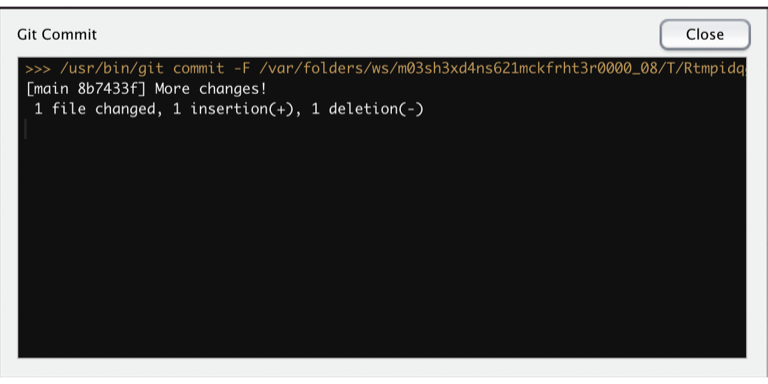

Go back to your browser and recheck the README file on your Github repository and you should see your changes appear (refresh the browser page if they are not there).

Now let’s add an R script. In RStudio, click [File] > [New File] > [R Script] to open a blank R script. Add the following R code to this script:

```r
x = rnorm(100, mean = 20, sd = 5)
y = x + rnorm(100, mean = 0, sd = 2)

fit = lm(y ~ x)

summary(fit)
```

This simply generates some correlated random numbers and builds a linear model between them, and prints out the results of that model. Save the script file as `lmExample.R` and then click [Run] from the scripting window. This will run all the code and allow you to check for mistakes.

Now if you check your Git tab, you should now see this file, with a small ‘A’ to indicate this is a new file added to the repository. If all is ok, go through the same steps to commit the changes:

- Click on [Commit] from the Git tab
- Stage the files you want to push (the new R script)
- Add a commit message
- Push to GitHub
- Check that your changes made it

Let’s add a couple more changes. First, we’ll add code to plot the data, and the model fit to the end of the file:

```r
plot(x,y)
abline(fit, col=2)
```

Run to check your code (and the beautiful plot you get), and then commit and push your changes.

```r
getwd()
```

```r
co2 = read.csv("co2_mm_mlo.csv")
plot(co2$decdate, co2$interpolated, type='l', main="Mauna Loa CO2",
     xlab="Time", ylab="ppm")
lines(co2$decdate, co2$trend, col=2, lwd=2)
```

Save and run your script, and if it all works, commit and push this to GitHub. Finally, go back to your browser and check that everything has uploaded correctly.

# Deleting GitHub repositories

If you need to delete a git repository, you will need to both delete the local copy and the one hosted by GitHub. The local copy can be deleted like any normal folder on your computer. The remote copy can be deleted by going to the repository page on GitHub, clicking on [Settings], scrolling all the way down to the Danger Zone[^1], and selecting [Delete this repository].

# Exercise

There is no additional work to do for this module’s exercise. Simply submit the URL to your GitHub page, or to the repository you created.

# Files used in lab

## Mauna Loa CO2 data: *co2_mm_mlo.csv*

[output not shown]

[^1]: Sterling Archer approves of GitHub